# Risk Factor Analysis

## Outcome Variable

**Outcome Variable:** haz

## Predictor Variables

**Intervention Variable:** nchldlt5

**Adjustment Set:**

- arm
- W_mage
- meducyrs
- feducyrs
- hhwealth_quart
- hfoodsec
- W_mhtcm
- W_mwtkg
- W_mbmi
- W_nrooms
- W_parity
- impfloor
- impsan
- safeh20
- delta_W_mage
- delta_meducyrs
- delta_feducyrs
- delta_hhwealth_quart
- delta_hfoodsec
- delta_W_mhtcm
- delta_W_mwtkg
- delta_W_mbmi
- delta_W_nrooms
- delta_W_parity
- delta_impfloor
- delta_impsan
- delta_safeh20

## Stratifying Variables

The analysis was stratified on these variable(s):

- agecat
- studyid
- country

## Data Summary

| agecat | studyid | country | nchldlt5 | n_cell | n |
| --- | --- | --- | --- | --- | --- |
| Birth | ki1000108-IRC | INDIA | 1 | 84 | 388 |
| Birth | ki1000108-IRC | INDIA | 2+ | 304 | 388 |
| Birth | ki1017093b-PROVIDE | BANGLADESH | 1 | 391 | 539 |
| Birth | ki1017093b-PROVIDE | BANGLADESH | 2+ | 148 | 539 |
| Birth | ki1017093c-NIH-Crypto | BANGLADESH | 1 | 522 | 732 |
| Birth | ki1017093c-NIH-Crypto | BANGLADESH | 2+ | 210 | 732 |
| Birth | kiGH5241-JiVitA-3 | BANGLADESH | 1 | 13986 | 22431 |
| Birth | kiGH5241-JiVitA-3 | BANGLADESH | 2+ | 8445 | 22431 |
| 6 months | ki1000108-IRC | INDIA | 1 | 89 | 407 |
| 6 months | ki1000108-IRC | INDIA | 2+ | 318 | 407 |
| 6 months | ki1017093b-PROVIDE | BANGLADESH | 1 | 438 | 604 |
| 6 months | ki1017093b-PROVIDE | BANGLADESH | 2+ | 166 | 604 |
| 6 months | ki1017093c-NIH-Crypto | BANGLADESH | 1 | 507 | 715 |
| 6 months | ki1017093c-NIH-Crypto | BANGLADESH | 2+ | 208 | 715 |
| 6 months | ki1066203-TanzaniaChild2 | TANZANIA, UNITED REPUBLIC OF | 1 | 1391 | 2020 |
| 6 months | ki1066203-TanzaniaChild2 | TANZANIA, UNITED REPUBLIC OF | 2+ | 629 | 2020 |
| 6 months | ki1148112-LCNI-5 | MALAWI | 1 | 390 | 811 |
| 6 months | ki1148112-LCNI-5 | MALAWI | 2+ | 421 | 811 |
| 6 months | kiGH5241-JiVitA-3 | BANGLADESH | 1 | 10887 | 16800 |
| 6 months | kiGH5241-JiVitA-3 | BANGLADESH | 2+ | 5913 | 16800 |
| 24 months | ki1000108-IRC | INDIA | 1 | 89 | 409 |
| 24 months | ki1000108-IRC | INDIA | 2+ | 320 | 409 |
| 24 months | ki1017093b-PROVIDE | BANGLADESH | 1 | 424 | 578 |
| 24 months | ki1017093b-PROVIDE | BANGLADESH | 2+ | 154 | 578 |
| 24 months | ki1017093c-NIH-Crypto | BANGLADESH | 1 | 357 | 514 |
| 24 months | ki1017093c-NIH-Crypto | BANGLADESH | 2+ | 157 | 514 |
| 24 months | ki1066203-TanzaniaChild2 | TANZANIA, UNITED REPUBLIC OF | 1 | 5 | 6 |
| 24 months | ki1066203-TanzaniaChild2 | TANZANIA, UNITED REPUBLIC OF | 2+ | 1 | 6 |
| 24 months | ki1148112-LCNI-5 | MALAWI | 1 | 283 | 571 |
| 24 months | ki1148112-LCNI-5 | MALAWI | 2+ | 288 | 571 |
| 24 months | kiGH5241-JiVitA-3 | BANGLADESH | 1 | 5454 | 8622 |
| 24 months | kiGH5241-JiVitA-3 | BANGLADESH | 2+ | 3168 | 8622 |

The following strata were considered:

- agecat: 24 months, studyid: ki1000108-IRC, country: INDIA
- agecat: 24 months, studyid: ki1017093b-PROVIDE, country: BANGLADESH
- agecat: 24 months, studyid: ki1017093c-NIH-Crypto, country: BANGLADESH
- agecat: 24 months, studyid: ki1066203-TanzaniaChild2, country: TANZANIA, UNITED REPUBLIC OF
- agecat: 24 months, studyid: ki1148112-LCNI-5, country: MALAWI
- agecat: 24 months, studyid: kiGH5241-JiVitA-3, country: BANGLADESH
- agecat: 6 months, studyid: ki1000108-IRC, country: INDIA
- agecat: 6 months, studyid: ki1017093b-PROVIDE, country: BANGLADESH
- agecat: 6 months, studyid: ki1017093c-NIH-Crypto, country: BANGLADESH
- agecat: 6 months, studyid: ki1066203-TanzaniaChild2, country: TANZANIA, UNITED REPUBLIC OF
- agecat: 6 months, studyid: ki1148112-LCNI-5, country: MALAWI
- agecat: 6 months, studyid: kiGH5241-JiVitA-3, country: BANGLADESH
- agecat: Birth, studyid: ki1000108-IRC, country: INDIA
- agecat: Birth, studyid: ki1017093b-PROVIDE, country: BANGLADESH
- agecat: Birth, studyid: ki1017093c-NIH-Crypto, country: BANGLADESH
- agecat: Birth, studyid: kiGH5241-JiVitA-3, country: BANGLADESH

### Dropped Strata

Some strata were dropped due to rare outcomes:

- agecat: 24 months, studyid: ki1066203-TanzaniaChild2, country: TANZANIA, UNITED REPUBLIC OF

## Methods Detail

We’re interested in the causal parameters $E[Y_a]$ for all values of $a \in \mathcal{A}$. These parameters represent the mean outcome if, possibly contrary to fact, we intervened to set all units to have $A=a$. Under the randomization and positivity assumptions, these are identified by the statistical parameters $\psi_a=E_W[E_{Y|A,W}(Y|A=a,W)]$. In addition, we’re interested in the mean of $Y$, $E[Y]$ under no intervention (the observed mean). We will estimate these parameters by using SuperLearner to fit the relevant likelihood factors – $E_{Y|A,W}(Y|A=a,W)$ and $p(A=a|W)$, and then updating our likelihood fit using a joint TMLE.

For unadjusted analyses ($W=\{\}$), initial likelihoods were estimated using Lrnr_glm to estimate the simple $E(Y|A)$ and Lrnr_mean to estimate $p(A)$. For adjusted analyses, a small library containing Lrnr_glmnet, Lrnr_xgboost, and Lrnr_mean was used.

Having estimated these parameters, we will then use the delta method to estimate relative risks and attributable risks relative to a prespecified baseline level of $A$.

# Results Detail

## Results Plots

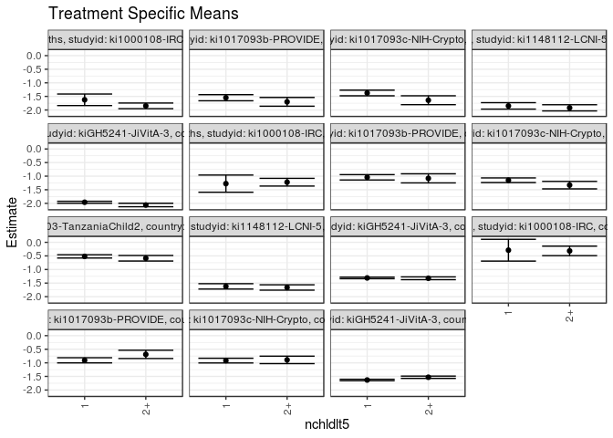

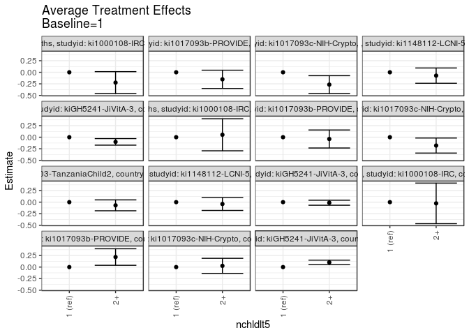

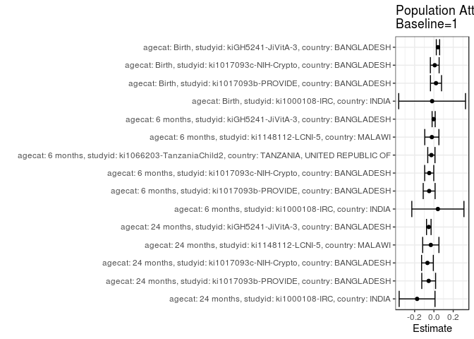

## Results Table

### Parameter: TSM

| agecat | studyid | country | intervention_level | baseline_level | estimate | ci_lower | ci_upper |
| --- | --- | --- | --- | --- | --- | --- | --- |
| Birth | ki1000108-IRC | INDIA | 1 | NA | -0.2892343 | -0.6906568 | 0.1121882 |
| Birth | ki1000108-IRC | INDIA | 2+ | NA | -0.3159374 | -0.4912306 | -0.1406442 |
| Birth | ki1017093b-PROVIDE | BANGLADESH | 1 | NA | -0.9065236 | -1.0012387 | -0.8118085 |
| Birth | ki1017093b-PROVIDE | BANGLADESH | 2+ | NA | -0.6894722 | -0.8414351 | -0.5375093 |
| Birth | ki1017093c-NIH-Crypto | BANGLADESH | 1 | NA | -0.9180649 | -1.0047819 | -0.8313480 |
| Birth | ki1017093c-NIH-Crypto | BANGLADESH | 2+ | NA | -0.8914842 | -1.0292801 | -0.7536883 |
| Birth | kiGH5241-JiVitA-3 | BANGLADESH | 1 | NA | -1.6315593 | -1.6587224 | -1.6043962 |
| Birth | kiGH5241-JiVitA-3 | BANGLADESH | 2+ | NA | -1.5303013 | -1.5721720 | -1.4884305 |
| 6 months | ki1000108-IRC | INDIA | 1 | NA | -1.2753877 | -1.5918069 | -0.9589686 |
| 6 months | ki1000108-IRC | INDIA | 2+ | NA | -1.2223397 | -1.3648491 | -1.0798302 |
| 6 months | ki1017093b-PROVIDE | BANGLADESH | 1 | NA | -1.0423072 | -1.1407006 | -0.9439139 |
| 6 months | ki1017093b-PROVIDE | BANGLADESH | 2+ | NA | -1.0811162 | -1.2486560 | -0.9135764 |
| 6 months | ki1017093c-NIH-Crypto | BANGLADESH | 1 | NA | -1.1499312 | -1.2358515 | -1.0640109 |
| 6 months | ki1017093c-NIH-Crypto | BANGLADESH | 2+ | NA | -1.3301173 | -1.4682735 | -1.1919612 |
| 6 months | ki1066203-TanzaniaChild2 | TANZANIA, UNITED REPUBLIC OF | 1 | NA | -0.5177725 | -0.5779878 | -0.4575571 |
| 6 months | ki1066203-TanzaniaChild2 | TANZANIA, UNITED REPUBLIC OF | 2+ | NA | -0.5865485 | -0.6886071 | -0.4844899 |
| 6 months | ki1148112-LCNI-5 | MALAWI | 1 | NA | -1.6214832 | -1.7199591 | -1.5230073 |
| 6 months | ki1148112-LCNI-5 | MALAWI | 2+ | NA | -1.6615487 | -1.7601999 | -1.5628975 |
| 6 months | kiGH5241-JiVitA-3 | BANGLADESH | 1 | NA | -1.3102919 | -1.3384177 | -1.2821661 |
| 6 months | kiGH5241-JiVitA-3 | BANGLADESH | 2+ | NA | -1.3229587 | -1.3743610 | -1.2715564 |
| 24 months | ki1000108-IRC | INDIA | 1 | NA | -1.6243621 | -1.8372683 | -1.4114559 |
| 24 months | ki1000108-IRC | INDIA | 2+ | NA | -1.8476769 | -1.9517144 | -1.7436394 |
| 24 months | ki1017093b-PROVIDE | BANGLADESH | 1 | NA | -1.5481482 | -1.6609910 | -1.4353054 |
| 24 months | ki1017093b-PROVIDE | BANGLADESH | 2+ | NA | -1.7000136 | -1.8611053 | -1.5389218 |
| 24 months | ki1017093c-NIH-Crypto | BANGLADESH | 1 | NA | -1.3741778 | -1.4782639 | -1.2700916 |
| 24 months | ki1017093c-NIH-Crypto | BANGLADESH | 2+ | NA | -1.6408987 | -1.8039773 | -1.4778202 |
| 24 months | ki1148112-LCNI-5 | MALAWI | 1 | NA | -1.8483103 | -1.9669718 | -1.7296489 |
| 24 months | ki1148112-LCNI-5 | MALAWI | 2+ | NA | -1.9205117 | -2.0349064 | -1.8061170 |
| 24 months | kiGH5241-JiVitA-3 | BANGLADESH | 1 | NA | -1.9603275 | -1.9971987 | -1.9234562 |
| 24 months | kiGH5241-JiVitA-3 | BANGLADESH | 2+ | NA | -2.0609620 | -2.1249668 | -1.9969571 |

### Parameter: E(Y)

| agecat | studyid | country | intervention_level | baseline_level | estimate | ci_lower | ci_upper |
| --- | --- | --- | --- | --- | --- | --- | --- |
| Birth | ki1000108-IRC | INDIA | NA | NA | -0.3080412 | -0.4687931 | -0.1472894 |
| Birth | ki1017093b-PROVIDE | BANGLADESH | NA | NA | -0.8851020 | -0.9601332 | -0.8100709 |
| Birth | ki1017093c-NIH-Crypto | BANGLADESH | NA | NA | -0.9094945 | -0.9809370 | -0.8380521 |
| Birth | kiGH5241-JiVitA-3 | BANGLADESH | NA | NA | -1.5897031 | -1.6089786 | -1.5704276 |
| 6 months | ki1000108-IRC | INDIA | NA | NA | -1.2344062 | -1.3658524 | -1.1029600 |
| 6 months | ki1017093b-PROVIDE | BANGLADESH | NA | NA | -1.0916915 | -1.1661176 | -1.0172654 |
| 6 months | ki1017093c-NIH-Crypto | BANGLADESH | NA | NA | -1.1986783 | -1.2700937 | -1.1272630 |
| 6 months | ki1066203-TanzaniaChild2 | TANZANIA, UNITED REPUBLIC OF | NA | NA | -0.5442232 | -0.5932373 | -0.4952090 |
| 6 months | ki1148112-LCNI-5 | MALAWI | NA | NA | -1.6431566 | -1.7128296 | -1.5734836 |
| 6 months | kiGH5241-JiVitA-3 | BANGLADESH | NA | NA | -1.3131375 | -1.3362767 | -1.2899983 |
| 24 months | ki1000108-IRC | INDIA | NA | NA | -1.7987775 | -1.8923914 | -1.7051636 |
| 24 months | ki1017093b-PROVIDE | BANGLADESH | NA | NA | -1.6024221 | -1.6857420 | -1.5191023 |
| 24 months | ki1017093c-NIH-Crypto | BANGLADESH | NA | NA | -1.4412646 | -1.5249156 | -1.3576135 |
| 24 months | ki1148112-LCNI-5 | MALAWI | NA | NA | -1.8806830 | -1.9625334 | -1.7988326 |
| 24 months | kiGH5241-JiVitA-3 | BANGLADESH | NA | NA | -2.0134284 | -2.0411019 | -1.9857549 |

### Parameter: ATE

| agecat | studyid | country | intervention_level | baseline_level | estimate | ci_lower | ci_upper |
| --- | --- | --- | --- | --- | --- | --- | --- |
| Birth | ki1000108-IRC | INDIA | 1 | 1 | 0.0000000 | 0.0000000 | 0.0000000 |
| Birth | ki1000108-IRC | INDIA | 2+ | 1 | -0.0267031 | -0.4657477 | 0.4123415 |
| Birth | ki1017093b-PROVIDE | BANGLADESH | 1 | 1 | 0.0000000 | 0.0000000 | 0.0000000 |
| Birth | ki1017093b-PROVIDE | BANGLADESH | 2+ | 1 | 0.2170514 | 0.0383054 | 0.3957974 |
| Birth | ki1017093c-NIH-Crypto | BANGLADESH | 1 | 1 | 0.0000000 | 0.0000000 | 0.0000000 |
| Birth | ki1017093c-NIH-Crypto | BANGLADESH | 2+ | 1 | 0.0265807 | -0.1358607 | 0.1890222 |
| Birth | kiGH5241-JiVitA-3 | BANGLADESH | 1 | 1 | 0.0000000 | 0.0000000 | 0.0000000 |
| Birth | kiGH5241-JiVitA-3 | BANGLADESH | 2+ | 1 | 0.1012580 | 0.0528115 | 0.1497045 |
| 6 months | ki1000108-IRC | INDIA | 1 | 1 | 0.0000000 | 0.0000000 | 0.0000000 |
| 6 months | ki1000108-IRC | INDIA | 2+ | 1 | 0.0530481 | -0.2934831 | 0.3995793 |
| 6 months | ki1017093b-PROVIDE | BANGLADESH | 1 | 1 | 0.0000000 | 0.0000000 | 0.0000000 |
| 6 months | ki1017093b-PROVIDE | BANGLADESH | 2+ | 1 | -0.0388090 | -0.2332908 | 0.1556729 |
| 6 months | ki1017093c-NIH-Crypto | BANGLADESH | 1 | 1 | 0.0000000 | 0.0000000 | 0.0000000 |
| 6 months | ki1017093c-NIH-Crypto | BANGLADESH | 2+ | 1 | -0.1801861 | -0.3429700 | -0.0174023 |
| 6 months | ki1066203-TanzaniaChild2 | TANZANIA, UNITED REPUBLIC OF | 1 | 1 | 0.0000000 | 0.0000000 | 0.0000000 |
| 6 months | ki1066203-TanzaniaChild2 | TANZANIA, UNITED REPUBLIC OF | 2+ | 1 | -0.0687761 | -0.1864459 | 0.0488937 |
| 6 months | ki1148112-LCNI-5 | MALAWI | 1 | 1 | 0.0000000 | 0.0000000 | 0.0000000 |
| 6 months | ki1148112-LCNI-5 | MALAWI | 2+ | 1 | -0.0400655 | -0.1794703 | 0.0993392 |
| 6 months | kiGH5241-JiVitA-3 | BANGLADESH | 1 | 1 | 0.0000000 | 0.0000000 | 0.0000000 |
| 6 months | kiGH5241-JiVitA-3 | BANGLADESH | 2+ | 1 | -0.0126668 | -0.0669509 | 0.0416173 |
| 24 months | ki1000108-IRC | INDIA | 1 | 1 | 0.0000000 | 0.0000000 | 0.0000000 |
| 24 months | ki1000108-IRC | INDIA | 2+ | 1 | -0.2233148 | -0.4601682 | 0.0135386 |
| 24 months | ki1017093b-PROVIDE | BANGLADESH | 1 | 1 | 0.0000000 | 0.0000000 | 0.0000000 |
| 24 months | ki1017093b-PROVIDE | BANGLADESH | 2+ | 1 | -0.1518653 | -0.3486966 | 0.0449659 |
| 24 months | ki1017093c-NIH-Crypto | BANGLADESH | 1 | 1 | 0.0000000 | 0.0000000 | 0.0000000 |
| 24 months | ki1017093c-NIH-Crypto | BANGLADESH | 2+ | 1 | -0.2667210 | -0.4601213 | -0.0733207 |
| 24 months | ki1148112-LCNI-5 | MALAWI | 1 | 1 | 0.0000000 | 0.0000000 | 0.0000000 |
| 24 months | ki1148112-LCNI-5 | MALAWI | 2+ | 1 | -0.0722014 | -0.2371577 | 0.0927550 |
| 24 months | kiGH5241-JiVitA-3 | BANGLADESH | 1 | 1 | 0.0000000 | 0.0000000 | 0.0000000 |
| 24 months | kiGH5241-JiVitA-3 | BANGLADESH | 2+ | 1 | -0.1006345 | -0.1713323 | -0.0299367 |

### Parameter: PAR

| agecat | studyid | country | intervention_level | baseline_level | estimate | ci_lower | ci_upper |
| --- | --- | --- | --- | --- | --- | --- | --- |
| Birth | ki1000108-IRC | INDIA | 1 | NA | -0.0188069 | -0.3649879 | 0.3273740 |
| Birth | ki1017093b-PROVIDE | BANGLADESH | 1 | NA | 0.0214216 | -0.0358923 | 0.0787354 |
| Birth | ki1017093c-NIH-Crypto | BANGLADESH | 1 | NA | 0.0085704 | -0.0368211 | 0.0539619 |
| Birth | kiGH5241-JiVitA-3 | BANGLADESH | 1 | NA | 0.0418562 | 0.0247004 | 0.0590121 |
| 6 months | ki1000108-IRC | INDIA | 1 | NA | 0.0409815 | -0.2292441 | 0.3112071 |
| 6 months | ki1017093b-PROVIDE | BANGLADESH | 1 | NA | -0.0493843 | -0.1111183 | 0.0123498 |
| 6 months | ki1017093c-NIH-Crypto | BANGLADESH | 1 | NA | -0.0487471 | -0.0958725 | -0.0016217 |
| 6 months | ki1066203-TanzaniaChild2 | TANZANIA, UNITED REPUBLIC OF | 1 | NA | -0.0264507 | -0.0640002 | 0.0110987 |
| 6 months | ki1148112-LCNI-5 | MALAWI | 1 | NA | -0.0216734 | -0.0949628 | 0.0516160 |
| 6 months | kiGH5241-JiVitA-3 | BANGLADESH | 1 | NA | -0.0028456 | -0.0188821 | 0.0131909 |
| 24 months | ki1000108-IRC | INDIA | 1 | NA | -0.1744154 | -0.3602134 | 0.0113826 |
| 24 months | ki1017093b-PROVIDE | BANGLADESH | 1 | NA | -0.0542739 | -0.1259650 | 0.0174172 |
| 24 months | ki1017093c-NIH-Crypto | BANGLADESH | 1 | NA | -0.0670868 | -0.1278406 | -0.0063330 |
| 24 months | ki1148112-LCNI-5 | MALAWI | 1 | NA | -0.0323727 | -0.1166901 | 0.0519447 |
| 24 months | kiGH5241-JiVitA-3 | BANGLADESH | 1 | NA | -0.0531010 | -0.0766674 | -0.0295346 |